# Prosper Loan Data

## by Pin

## Investigation Overview

Make people understand the relationship between the rating of the loan and the character of the borrower. With a understanding on the type of loan the platform given out.

## Dataset Overview

This dataset is a data set of a loan request made on the prosper platform. The detail of the loan are describe in the dataset such as how much it was borrowed, the rate that the borrower pay, the status and time of the payment. The dataset mainly focuses on the characteristic of each loan that were requested in the platform.

## Inspection of the Credit rating different

I want to find whether the credit rating of the prosper and normmal credit rating are different or not. As a result we can see that the prosper credit rating have a stricter standard of getting an AA whereas the credit grade are not. But overall the distribution seems to be quite similar so we stick with the prosper rating alpha for our analysis.

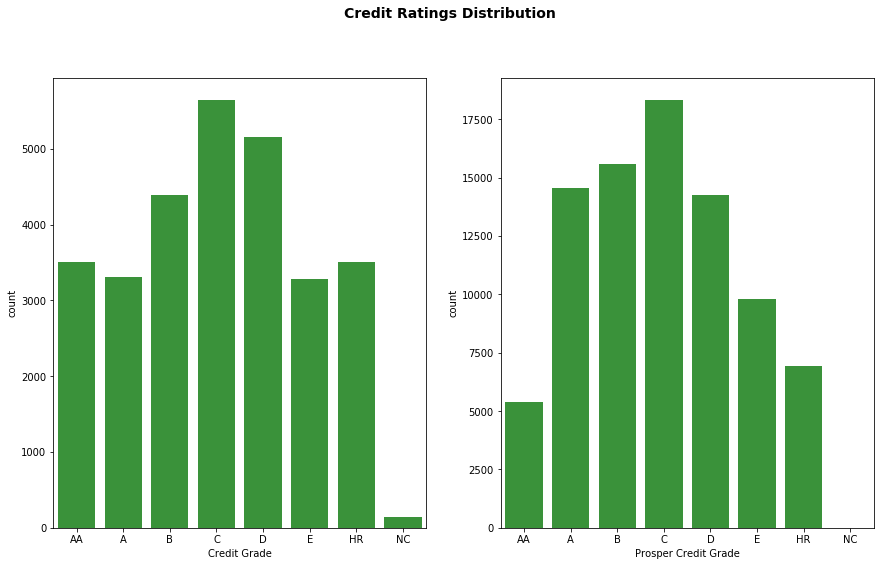

```python
rating=['AA','A','B','C','D','E','HR','NC']

rating_order=pd.api.types.CategoricalDtype(ordered=True,categories=rating)
df['CreditGrade']=df['CreditGrade'].astype(rating_order);
df['ProsperRating (Alpha)']=df['ProsperRating (Alpha)'].astype(rating_order);

#different between each rating category
plt.figure(figsize=[14.70, 8.27])
base=sb.color_palette()[2]

plt.subplot(1,2,1)

sb.countplot(data=df,x='CreditGrade',color=base);
plt.xlabel("Credit Grade")


plt.subplot(1,2,2)
sb.countplot(data=df,x='ProsperRating (Alpha)',color=base);
plt.xlabel("Prosper Credit Grade")

plt.suptitle("Credit Ratings Distribution", fontsize = 14, weight = "bold", y = 1);
```

## Time base analysis of the loan

We can clearly sees that the distribution of the loan orgination suddenly drop during the time of crisis and come back during the 2012-2013 period. While the period that the loan normally grant are at 36 month.

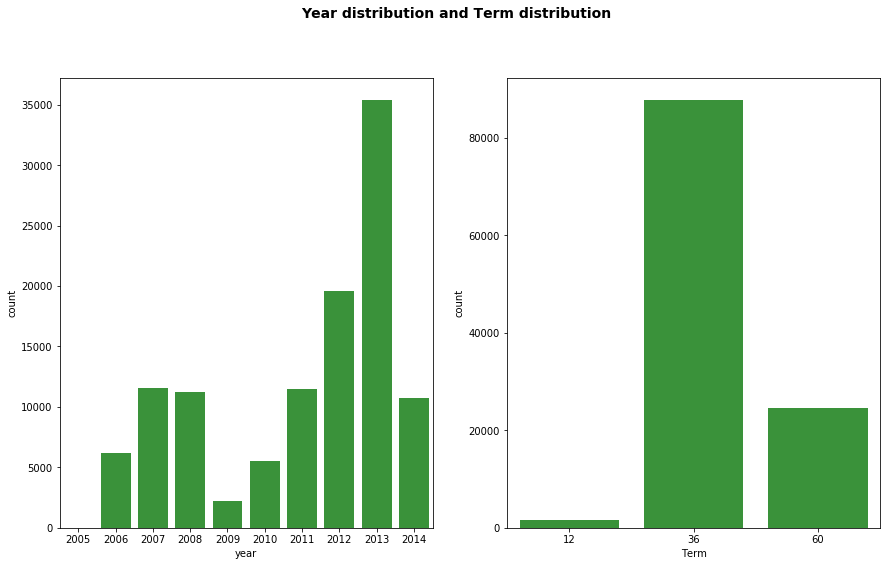

```python
plt.figure(figsize=[14.70, 8.27])
plt.subplot(1,2,1)

sb.countplot(data=df,x='year',color=base);

plt.subplot(1,2,2)
sb.countplot(data=df,x='Term',color=base);

plt.suptitle('Year distribution and Term distribution', fontsize = 14, weight = "bold", y = 1);
```

## Type of Loan given (based on purpose)

Most loan given are for Debt consolidation which get highest average loan amount comparing to the other category followed by Business loan

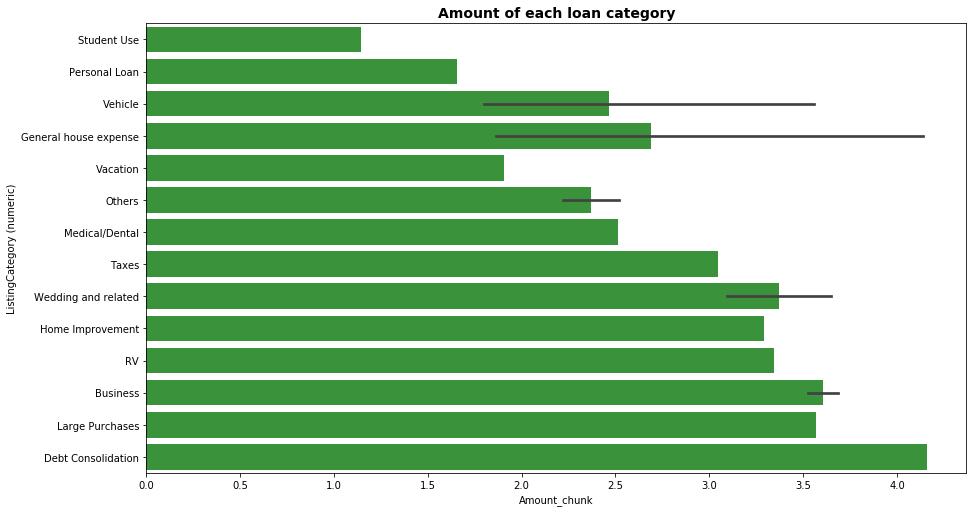

```python
plt.figure(figsize=[14.70, 8.27])

sb.barplot(data=amountc,x='Amount_chunk',y='ListingCategory (numeric)',color=base);

plt.title('Amount of each loan category', fontsize = 14, weight = "bold", y = 1);
```

## Rating and yield

We can observe from the data that the higher the rating the lower the rate for borrower and the higher the loan amount given. This seems to be a logical relationship since the higher rating should have lower default probability thus higher amount given.

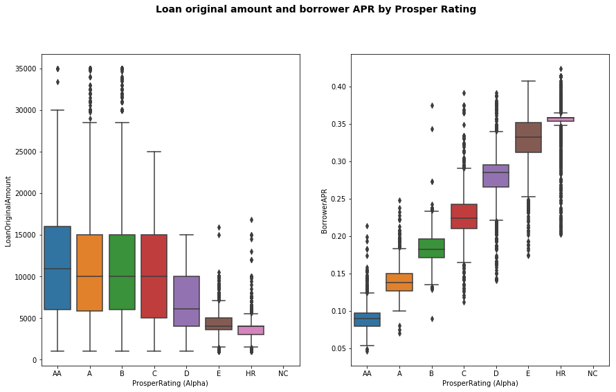

```python
plt.figure(figsize=[14.70, 8.27])

plt.subplot(1,2,1)
ax1=sb.boxplot(data=df,x='ProsperRating (Alpha)',y='LoanOriginalAmount');

plt.subplot(1,2,2)
sb.boxplot(data=df,x='ProsperRating (Alpha)',y='BorrowerAPR');

plt.suptitle('Loan original amount and borrower APR by Prosper Rating', fontsize = 14, weight = "bold", y = 1);
```

## Rating, Default

We could see that the higher the rating the lower the default probabilitly. But this came with exception of the A Grade which has higher default probability than B and C grade. The reason that might be behind this is that higher proportion of loan are given at A grade, although this default probability has been in % of total loan given per grades. But it still haven't eliminate this effect. Showing that the A grade really have higher default probability

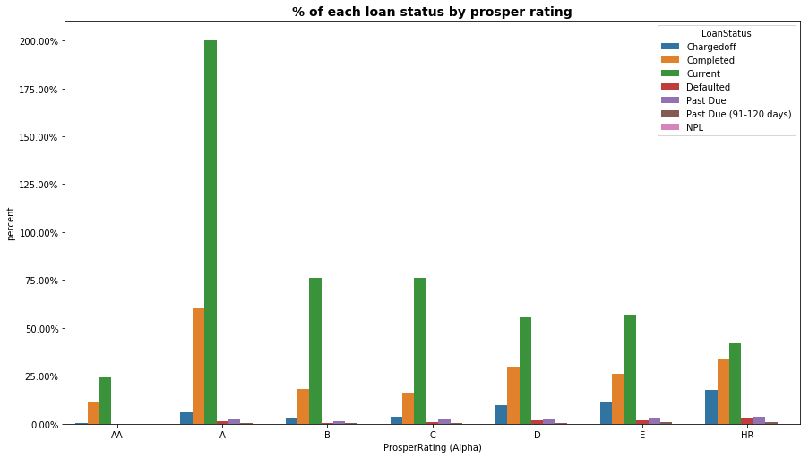

```python
plt.figure(figsize=[14.70, 8.27])
ax=sb.barplot(data=rating_cat,x='ProsperRating (Alpha)',y='percent',hue='LoanCat');
y_value=['{:,.2f}'.format(x*100) + '%' for x in ax.get_yticks()]
ax.set_yticklabels(y_value);
plt.title('% of each loan status by prosper rating', fontsize = 14, weight = "bold", y = 1);
ax.legend(title='LoanStatus');
```

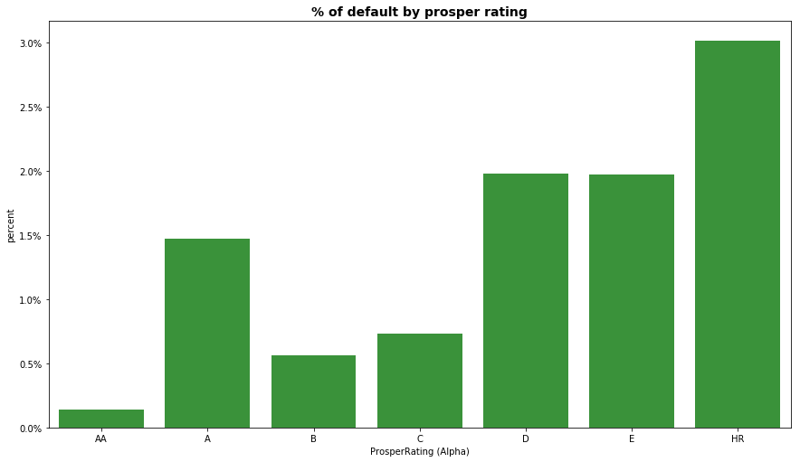

```python
plt.figure(figsize=[14.70, 8.27])
ax1=sb.barplot(data=default_cat,x='ProsperRating (Alpha)',y='percent',color=base);
y_value=['{:,.1f}'.format(x*100) + '%' for x in ax1.get_yticks()]
plt.title('% of default by prosper rating', fontsize = 14, weight = "bold", y = 1);

ax1.set_yticklabels(y_value);
```

## Character of the Borrower

Occupation didn't effect the rating, given that the rating are evenly distribute within each and every occupation The state that has higher income has propbability that the average rating of the state is higher

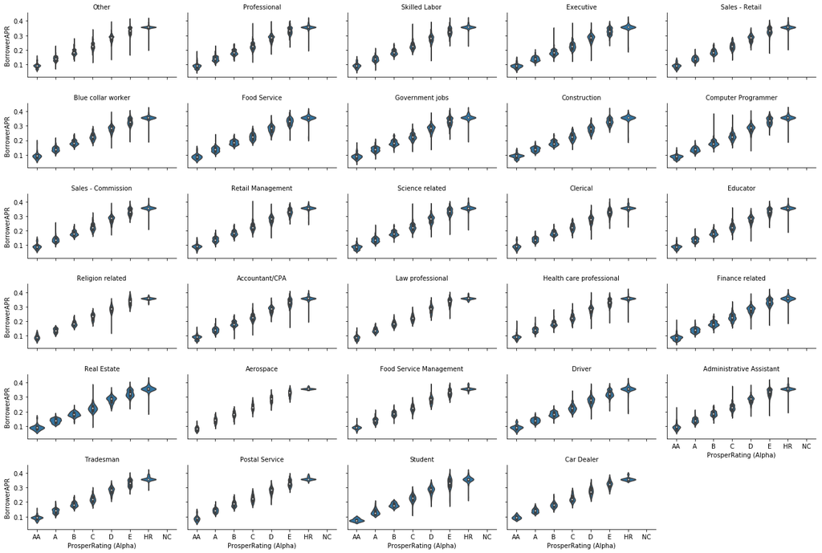

```python
rating=['AA','A','B','C','D','E','HR','NC']

rating_order=pd.api.types.CategoricalDtype(ordered=True,categories=rating)
df_clean['CreditGrade']=df_clean['CreditGrade'].astype(rating_order);
df_clean['ProsperRating (Alpha)']=df_clean['ProsperRating (Alpha)'].astype(rating_order);

#occupation


g=sb.FacetGrid(data=df_clean,col="Occupation",col_wrap=5 ,height = 8.27/4,  aspect = (14.70/5)/(8.27/5));



g.map(sb.violinplot,'ProsperRating (Alpha)','BorrowerAPR');
g.set_titles('{col_name}');
```

```python
#by State

scl = [
    [0.0, 'rgb(242,240,247)'],
    [0.2, 'rgb(218,218,235)'],
    [0.4, 'rgb(188,189,220)'],
    [0.6, 'rgb(158,154,200)'],
    [0.8, 'rgb(117,107,177)'],
    [1.0, 'rgb(84,39,143)']
]



data = [go.Choropleth(
    colorscale = scl,
    autocolorscale = False,
    locations = df_clean_state['BorrowerState'],
    z = df_clean_state['ProsperRating (numeric)'].astype(float),
    locationmode = 'USA-states',
    text = df_clean_state['text'],
    marker = go.choropleth.Marker(
        line = go.choropleth.marker.Line(
            color = 'rgb(255,255,255)',
            width = 2
        )),
    colorbar = go.choropleth.ColorBar(
        title = "Rating")
)]

layout = go.Layout(
    title = go.layout.Title(
        text = 'Rating By State<br>(Hover for breakdown)'
    ),
    geo = go.layout.Geo(
        scope = 'usa',
        projection = go.layout.geo.Projection(type = 'albers usa'),
        showlakes = True,
        lakecolor = 'rgb(255, 255, 255)'),
)

fig = go.Figure(data = data, layout = layout)
py.iplot(fig, filename = 'd3-cloropleth-map')
```

```
High five! You successfully sent some data to your account on plotly. View your plot in your browser at https://plot.ly/~aircop/0 or inside your plot.ly account where it is named 'd3-cloropleth-map'
```

[interactive chart not shown]